# 8 ANOVA

```r
# Set working directory
setwd("~/Dropbox/GitHub/ProbEstad2021")

library(rcompanion)
library(car)
library(emmeans)
library(hrbrthemes)
library(viridis)
library(rstatix)
library(tidyverse)
```

## Introducción ANOVA

Uno de los procesos más usados para comparar diferentes “tratamientos” sobre un grupo experimental es sin duda el Análisis de Varianza (ANOVA). Desarrollado originalmente por R.A. Fisher y ha tenido una gran influencia en la estadística. El análisis de varianza se usa principalmente para dos propósitos: 1) para estimar y desarrollar prueba de hipótesis de varianzas de una población. 2) Estimar y probar medias poblacionales. En esta introducción resolveremos ejemplos para la estimación de medias poblacionales.

## ANOVA Modelos de una via (One-Way ANOVA)

Carne proveniente de caza, entre otras aquellas del venado de cola-blanca, y ardilla gris, son usadas como alimento or familias, cazadores y otros individuos por razones culturales, personales, o de salud. EN un estudio de Holben et al. estimó el contenido de selenio de carne de venado cola-blanca libre (venison), y ardilla gris (squirrel) obtenidos de una región de baja concentración de selenio en EEUU. Estos contenidos de selenio fueron también comparados con concentraciones de carne de ganado producido en la misma región (RRB) y en una región externa (NRRB). Nos interesa saber si la concentración de selenio $(\mu g/100g)$ es distinta en los grupos de carne. (EXA_C08_S02_01.csv).

La hipótesis nula de este modelo es que todos los promedios poblacionales (cada promedio de la población de cada caso) son iguales entre ellos $\mu_1 = \mu_2 = \mu_3 \dots = \mu_n$, y la hipótesis alternativa es que “por lo menos uno de ellos es distinto”.

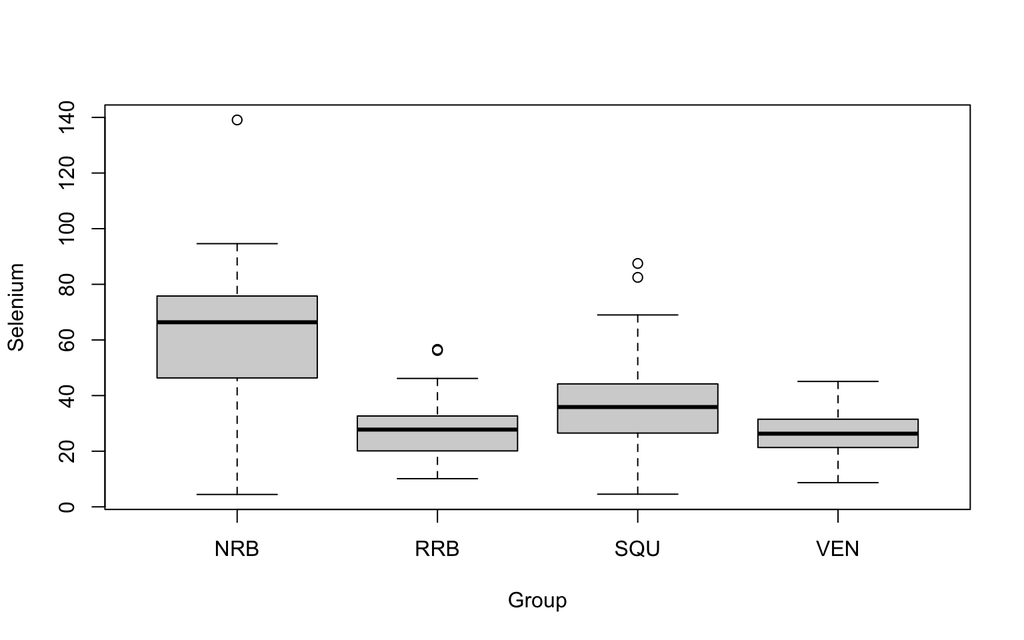

```r
# Exa_C08_S02_01 One-way
#
Exa8.2.1 <- read_csv(file="DataSets/ch08_all/EXA_C08_S02_01mod.csv")
boxplot(Selenium ~ Group, data = Exa8.2.1)
```

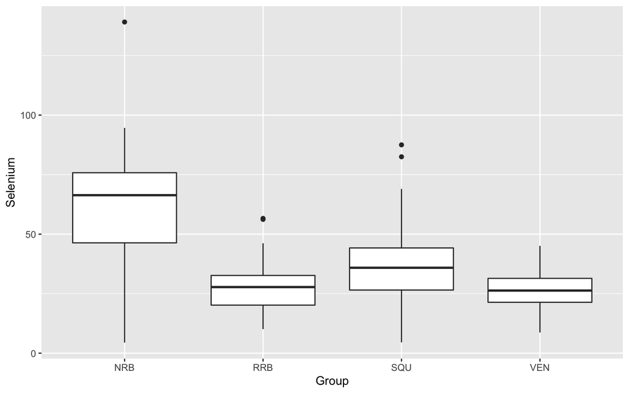

```r
ggplot(data = Exa8.2.1, aes(x = Group, y = Selenium)) + geom_boxplot()
```

```r
Exa8.2.1_lm <- lm(Selenium ~ Group, data = Exa8.2.1)
(anova_Exa8.2.1_lm <- anova(Exa8.2.1_lm))
```

```
Analysis of Variance Table

Response: Selenium
           Df Sum Sq Mean Sq F value    Pr(>F)
Group       3  18935  6311.7  22.614 5.345e-12 ***
Residuals 140  39074   279.1
---
Signif. codes:  0 '***' 0.001 '**' 0.01 '*' 0.05 '.' 0.1 ' ' 1
```

```r
#
Exa8.2.1_aov <- aov(Selenium ~ Group, data = Exa8.2.1)
#
summary(Exa8.2.1_aov)
```

```
             Df Sum Sq Mean Sq F value   Pr(>F)
Group         3  18935    6312   22.61 5.34e-12 ***
Residuals   140  39074     279
---
Signif. codes:  0 '***' 0.001 '**' 0.01 '*' 0.05 '.' 0.1 ' ' 1
```

```r
model.tables(Exa8.2.1_aov, type="means")
```

```
Tables of means
Grand mean

35.44736

 Group
      NRB   RRB   SQU   VEN
    62.05 28.52 37.42 25.88
rep 19.00 30.00 53.00 42.00
```

```r
model.tables(Exa8.2.1_aov, type="effects")
```

```
Tables of effects

 Group
     NRB    RRB   SQU    VEN
    26.6 -6.925  1.97 -9.572
rep 19.0 30.000 53.00 42.000
```

```r
#
TukeyHSD(Exa8.2.1_aov)
```

```
  Tukey multiple comparisons of means
    95% family-wise confidence level

Fit: aov(formula = Selenium ~ Group, data = Exa8.2.1)

$Group
              diff        lwr        upr     p adj
RRB-NRB -33.523982 -46.260203 -20.787762 0.0000000
SQU-NRB -24.629335 -36.244663 -13.014007 0.0000010
VEN-NRB -36.170840 -48.180851 -24.160828 0.0000000
SQU-RRB   8.894648  -1.030122  18.819418 0.0961032
VEN-RRB  -2.646857 -13.030768   7.737053 0.9108599
VEN-SQU -11.541505 -20.515363  -2.567647 0.0057777
```

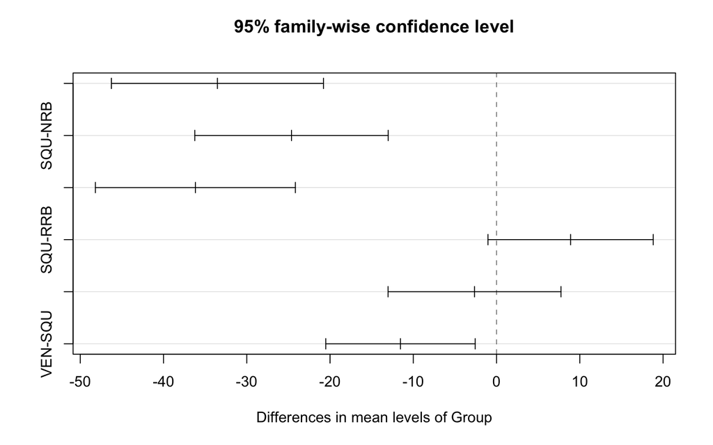

```r
plot(TukeyHSD(Exa8.2.1_aov))
```

**Más ejemplos**

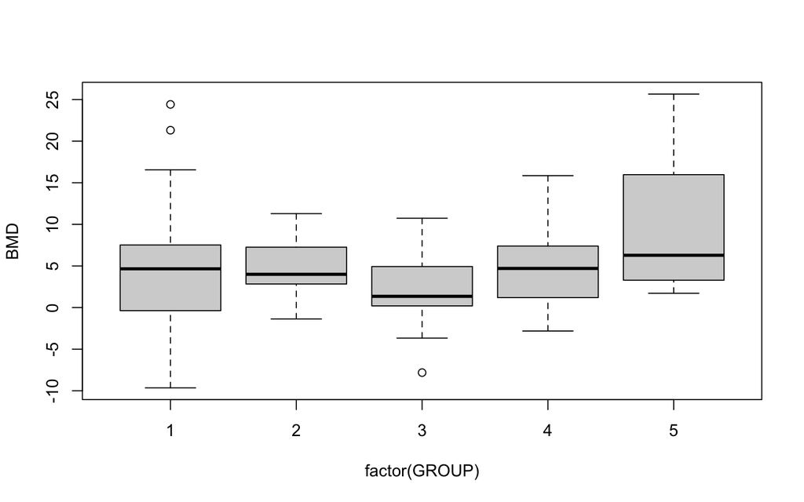

```r
# Exer. 8.2.2
# Patients suffering from rheumatic diseases or osteoporosis often suffer critical loss in bone
# mineral density (BMD).
#
EXR8.2.2 <- read_csv(file="DataSets/ch08_all/EXR_C08_S02_02.csv")
boxplot(BMD ~ factor(GROUP), data = EXR8.2.2)
```

```r
Exr2_2.aov <- aov(BMD ~ factor(GROUP), data=EXR8.2.2)
summary(Exr2_2.aov)
```

```
              Df Sum Sq Mean Sq F value Pr(>F)
factor(GROUP)  4    355   88.86   2.277  0.067 .
Residuals     91   3551   39.02
---
Signif. codes:  0 '***' 0.001 '**' 0.01 '*' 0.05 '.' 0.1 ' ' 1
```

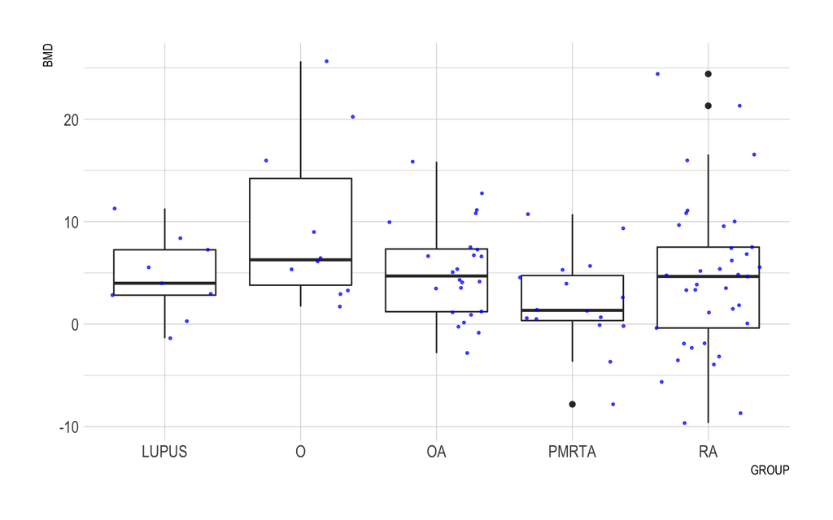

```r
#
EXR8.2.2_M <- EXR8.2.2 %>% mutate(GROUP = case_when(GROUP == 1 ~ "RA", GROUP == 2 ~ "LUPUS",
                                                    GROUP == 3 ~ "PMRTA", GROUP == 4 ~ "OA",
                                                    GROUP == 5 ~ "O"))

ggplot( data = EXR8.2.2_M, aes(x = GROUP, y = BMD) )  + geom_boxplot() +
  scale_fill_viridis(discrete = TRUE, alpha=0.6) +
  geom_jitter(color="blue", size=0.6, alpha=0.7) + theme_ipsum()
```

```r
#
Exr2_2_lm <- lm(BMD ~ factor(GROUP), data=EXR8.2.2_M)
S(Exr2_2_lm)
```

```
Call: lm(formula = BMD ~ factor(GROUP), data = EXR8.2.2_M)

Coefficients:
                   Estimate Std. Error t value Pr(>|t|)
(Intercept)          4.5780     2.0823   2.199   0.0304 *
factor(GROUP)O       5.0938     2.8702   1.775   0.0793 .
factor(GROUP)OA      0.6265     2.4417   0.257   0.7981
factor(GROUP)PMRTA  -2.3972     2.6029  -0.921   0.3595
factor(GROUP)RA     -0.1081     2.3218  -0.047   0.9630
---
Signif. codes:  0 '***' 0.001 '**' 0.01 '*' 0.05 '.' 0.1 ' ' 1

Residual standard deviation: 6.247 on 91 degrees of freedom
Multiple R-squared: 0.09099
F-statistic: 2.277 on 4 and 91 DF,  p-value: 0.06697
   AIC    BIC
631.06 646.45
```

```r
emmeans(Exr2_2_lm, pairwise ~ GROUP)
```

```
$emmeans
 GROUP emmean   SE df lower.CL upper.CL
 LUPUS   4.58 2.08 91    0.442     8.71
 O       9.67 1.98 91    5.748    13.60
 OA      5.20 1.28 91    2.672     7.74
 PMRTA   2.18 1.56 91   -0.921     5.28
 RA      4.47 1.03 91    2.430     6.51

Confidence level used: 0.95

$contrasts
 contrast      estimate   SE df t.ratio p.value
 LUPUS - O       -5.094 2.87 91  -1.775  0.3946
 LUPUS - OA      -0.627 2.44 91  -0.257  0.9990
 LUPUS - PMRTA    2.397 2.60 91   0.921  0.8881
 LUPUS - RA       0.108 2.32 91   0.047  1.0000
 O - OA           4.467 2.35 91   1.900  0.3248
 O - PMRTA        7.491 2.52 91   2.975  0.0301
 O - RA           5.202 2.23 91   2.336  0.1430
 OA - PMRTA       3.024 2.02 91   1.500  0.5653
 OA - RA          0.735 1.64 91   0.449  0.9915
 PMRTA - RA      -2.289 1.87 91  -1.225  0.7371

P value adjustment: tukey method for comparing a family of 5 estimates
```

```r
emmeans(Exr2_2_lm, trt.vs.ctrl ~ GROUP)
```

```
$emmeans
 GROUP emmean   SE df lower.CL upper.CL
 LUPUS   4.58 2.08 91    0.442     8.71
 O       9.67 1.98 91    5.748    13.60
 OA      5.20 1.28 91    2.672     7.74
 PMRTA   2.18 1.56 91   -0.921     5.28
 RA      4.47 1.03 91    2.430     6.51

Confidence level used: 0.95

$contrasts
 contrast      estimate   SE df t.ratio p.value
 O - LUPUS        5.094 2.87 91   1.775  0.2387
 OA - LUPUS       0.627 2.44 91   0.257  0.9858
 PMRTA - LUPUS   -2.397 2.60 91  -0.921  0.7333
 RA - LUPUS      -0.108 2.32 91  -0.047  0.9998

P value adjustment: dunnettx method for 4 tests
```

```r
# # # # # # # # # # # # # # # # # # # # # # # # # # # # # # # # # # # # #
# Exr 8.2.3
Exr8.2.3 <- read_csv(file="DataSets/ch08_all/EXR_C08_S02_03.csv")

Exr3.aov <- aov(calcium ~ Group, data=Exr8.2.3)
summary(Exr3.aov)
```

```
             Df   Sum Sq Mean Sq F value   Pr(>F)
Group         3  5931208 1977069   9.359 1.48e-05 ***
Residuals   109 23026500  211252
---
Signif. codes:  0 '***' 0.001 '**' 0.01 '*' 0.05 '.' 0.1 ' ' 1
```

```r
TukeyHSD(Exr3.aov)
```

```
  Tukey multiple comparisons of means
    95% family-wise confidence level

Fit: aov(formula = calcium ~ Group, data = Exr8.2.3)

$Group
          diff       lwr        upr     p adj
B-A -455.72078 -865.7066  -45.73492 0.0230454
C-A -574.53605 -913.5892 -235.48294 0.0001356
D-A -596.63447 -905.3867 -287.88228 0.0000109
C-B -118.81527 -509.0844  271.45386 0.8568796
D-B -140.91369 -505.1676  223.34020 0.7443051
D-C  -22.09842 -304.1436  259.94679 0.9969598
```

## ANOVA de dos vías

**Ejemplos two-way ANOVA** En un estudio de efectos pulmonares en conejillos de Indias, Lacroix et al. expuso a 18 conejillos de Indias sensibilizados con albúmina y 18 no-sensibilizados con aire regular, benzaldehido y acetildehido. Al final de la exposición los conejillos de Indias fueron anesteciados y la respuesta a alergias medida por lavado broncoalveolar (BAL). La tabla de resultados se muestra en REV_C08_16 y muestra la cuenta de células alveolares $(\times 10^6)$ por grupo de tratamiento (aire, benzaldehido y acetildehido) y sensibilizados a albúmina. Pruebe por las diferencias en a) entre sensibilizados y no sensibilizados por albúmina, b) entre los tres tratamientos. Sea $\alpha=.05$ en todas las pruebas.

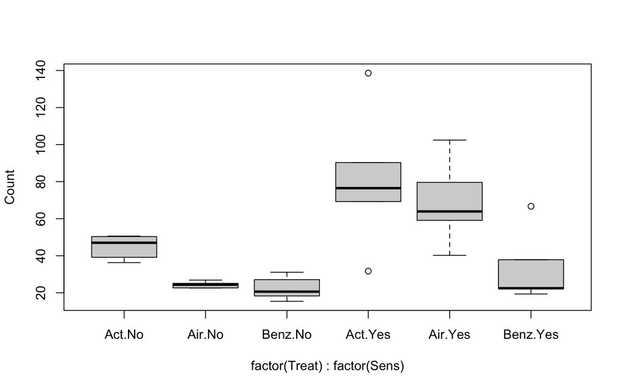

```r
Rev8.16 <- read_csv("DataSets/ch08_all/REV_C08_16.csv")
boxplot(Count ~ factor(Treat) + factor(Sens), data = Rev8.16)
```

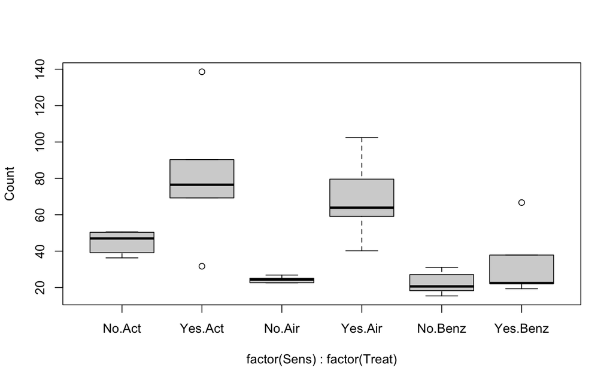

```r
boxplot(Count ~ factor(Sens) + factor(Treat), data = Rev8.16)
```

```r
#
Rev8.16_M <- Rev8.16 %>% mutate( Treat = case_when( Treat == "Air" ~ "1Air", Treat == "Act" ~ "2Act", Treat == "Benz" ~ "3Benz"))
Rev8.16_aov <- aov(Count ~ factor(Sens) + factor(Treat), data = Rev8.16)
summary(Rev8.16_aov)
```

```
              Df Sum Sq Mean Sq F value   Pr(>F)
factor(Sens)   1   7906    7906   20.72 7.28e-05 ***
factor(Treat)  2   7689    3844   10.07 0.000404 ***
Residuals     32  12212     382
---
Signif. codes:  0 '***' 0.001 '**' 0.01 '*' 0.05 '.' 0.1 ' ' 1
```

```r
#
# With car Anova
Rev8.16_lm <- lm(Count ~ factor(Sens) + factor(Treat), data = Rev8.16_M)
Anova(Rev8.16_lm)
```

```
Anova Table (Type II tests)

Response: Count
               Sum Sq Df F value    Pr(>F)
factor(Sens)   7906.2  1  20.718 7.276e-05 ***
factor(Treat)  7688.6  2  10.074 0.0004042 ***
Residuals     12211.5 32
---
Signif. codes:  0 '***' 0.001 '**' 0.01 '*' 0.05 '.' 0.1 ' ' 1
```

```r
#
S(Rev8.16_lm)
```

```
Call: lm(formula = Count ~ factor(Sens) + factor(Treat), data = Rev8.16_M)

Coefficients:
                   Estimate Std. Error t value Pr(>|t|)
(Intercept)          31.435      6.512   4.827 3.28e-05 ***
factor(Sens)Yes      29.639      6.512   4.552 7.28e-05 ***
factor(Treat)2Act    16.517      7.975   2.071   0.0465 *
factor(Treat)3Benz  -19.246      7.975  -2.413   0.0217 *
---
Signif. codes:  0 '***' 0.001 '**' 0.01 '*' 0.05 '.' 0.1 ' ' 1

Residual standard deviation: 19.53 on 32 degrees of freedom
Multiple R-squared: 0.5608
F-statistic: 13.62 on 3 and 32 DF,  p-value: 6.77e-06
   AIC    BIC
321.92 329.84
```

```r
emmeans(Rev8.16_lm, pairwise ~ Sens + Treat)
```

```
$emmeans
 Sens Treat emmean   SE df lower.CL upper.CL
 No   1Air    31.4 6.51 32    18.17     44.7
 Yes  1Air    61.1 6.51 32    47.81     74.3
 No   2Act    48.0 6.51 32    34.69     61.2
 Yes  2Act    77.6 6.51 32    64.33     90.9
 No   3Benz   12.2 6.51 32    -1.07     25.5
 Yes  3Benz   41.8 6.51 32    28.56     55.1

Confidence level used: 0.95

$contrasts
 contrast             estimate    SE df t.ratio p.value
 No 1Air - Yes 1Air     -29.64  6.51 32 -4.552  0.0009
 No 1Air - No 2Act      -16.52  7.98 32 -2.071  0.3273
 No 1Air - Yes 2Act     -46.16 10.30 32 -4.483  0.0012
 No 1Air - No 3Benz      19.25  7.98 32  2.413  0.1820
 No 1Air - Yes 3Benz    -10.39 10.30 32 -1.009  0.9114
 Yes 1Air - No 2Act      13.12 10.30 32  1.275  0.7963
 Yes 1Air - Yes 2Act    -16.52  7.98 32 -2.071  0.3273
 Yes 1Air - No 3Benz     48.88 10.30 32  4.748  0.0005
 Yes 1Air - Yes 3Benz    19.25  7.98 32  2.413  0.1820
 No 2Act - Yes 2Act     -29.64  6.51 32 -4.552  0.0009
 No 2Act - No 3Benz      35.76  7.98 32  4.484  0.0011
 No 2Act - Yes 3Benz      6.12 10.30 32  0.595  0.9907
 Yes 2Act - No 3Benz     65.40 10.30 32  6.352  <.0001
 [ reached getOption("max.print") -- omitted 2 rows ]

P value adjustment: tukey method for comparing a family of 6 estimates
```

```r
emmeans(Rev8.16_lm, trt.vs.ctrl ~ Sens + Treat)
```

```
$emmeans
 Sens Treat emmean   SE df lower.CL upper.CL
 No   1Air    31.4 6.51 32    18.17     44.7
 Yes  1Air    61.1 6.51 32    47.81     74.3
 No   2Act    48.0 6.51 32    34.69     61.2
 Yes  2Act    77.6 6.51 32    64.33     90.9
 No   3Benz   12.2 6.51 32    -1.07     25.5
 Yes  3Benz   41.8 6.51 32    28.56     55.1

Confidence level used: 0.95

$contrasts
 contrast            estimate    SE df t.ratio p.value
 Yes 1Air - No 1Air      29.6  6.51 32  4.552  0.0003
 No 2Act - No 1Air       16.5  7.98 32  2.071  0.1723
 Yes 2Act - No 1Air      46.2 10.30 32  4.483  0.0004
 No 3Benz - No 1Air     -19.2  7.98 32 -2.413  0.0868
 Yes 3Benz - No 1Air     10.4 10.30 32  1.009  0.7331

P value adjustment: dunnettx method for 5 tests
```

```r
#
Rev8.16_lm_int <- lm(Count ~ factor(Sens) * factor(Treat), data = Rev8.16_M)
S(Rev8.16_lm_int)
```

```
Call: lm(formula = Count ~ factor(Sens) * factor(Treat), data = Rev8.16_M)

Coefficients:
                                   Estimate Std. Error t value Pr(>|t|)
(Intercept)                          24.317      7.566   3.214 0.003123 **
factor(Sens)Yes                      43.875     10.699   4.101 0.000289 ***
factor(Treat)2Act                    20.750     10.699   1.939 0.061913 .
factor(Treat)3Benz                   -2.125     10.699  -0.199 0.843909
factor(Sens)Yes:factor(Treat)2Act    -8.467     15.131  -0.560 0.579942
factor(Sens)Yes:factor(Treat)3Benz  -34.242     15.131  -2.263 0.031036 *
---
Signif. codes:  0 '***' 0.001 '**' 0.01 '*' 0.05 '.' 0.1 ' ' 1

Residual standard deviation: 18.53 on 30 degrees of freedom
Multiple R-squared: 0.6295
F-statistic: 10.19 on 5 and 30 DF,  p-value: 8.851e-06
   AIC    BIC
319.80 330.89
```

```r
emmeans(Rev8.16_lm_int, pairwise ~ Sens + Treat)
```

```
$emmeans
 Sens Treat emmean   SE df lower.CL upper.CL
 No   1Air    24.3 7.57 30     8.87     39.8
 Yes  1Air    68.2 7.57 30    52.74     83.6
 No   2Act    45.1 7.57 30    29.62     60.5
 Yes  2Act    80.5 7.57 30    65.02     95.9
 No   3Benz   22.2 7.57 30     6.74     37.6
 Yes  3Benz   31.8 7.57 30    16.37     47.3

Confidence level used: 0.95

$contrasts
 contrast             estimate   SE df t.ratio p.value
 No 1Air - Yes 1Air     -43.88 10.7 30 -4.101  0.0036
 No 1Air - No 2Act      -20.75 10.7 30 -1.939  0.3993
 No 1Air - Yes 2Act     -56.16 10.7 30 -5.249  0.0002
 No 1Air - No 3Benz       2.12 10.7 30  0.199  1.0000
 No 1Air - Yes 3Benz     -7.51 10.7 30 -0.702  0.9803
 Yes 1Air - No 2Act      23.12 10.7 30  2.161  0.2850
 Yes 1Air - Yes 2Act    -12.28 10.7 30 -1.148  0.8572
 Yes 1Air - No 3Benz     46.00 10.7 30  4.299  0.0021
 Yes 1Air - Yes 3Benz    36.37 10.7 30  3.399  0.0215
 No 2Act - Yes 2Act     -35.41 10.7 30 -3.309  0.0268
 No 2Act - No 3Benz      22.88 10.7 30  2.138  0.2959
 No 2Act - Yes 3Benz     13.24 10.7 30  1.238  0.8150
 Yes 2Act - No 3Benz     58.28 10.7 30  5.447  0.0001
 [ reached getOption("max.print") -- omitted 2 rows ]

P value adjustment: tukey method for comparing a family of 6 estimates
```

```r
emmeans(Rev8.16_lm_int, trt.vs.ctrl ~ Sens + Treat)
```

```
$emmeans
 Sens Treat emmean   SE df lower.CL upper.CL
 No   1Air    24.3 7.57 30     8.87     39.8
 Yes  1Air    68.2 7.57 30    52.74     83.6
 No   2Act    45.1 7.57 30    29.62     60.5
 Yes  2Act    80.5 7.57 30    65.02     95.9
 No   3Benz   22.2 7.57 30     6.74     37.6
 Yes  3Benz   31.8 7.57 30    16.37     47.3

Confidence level used: 0.95

$contrasts
 contrast            estimate   SE df t.ratio p.value
 Yes 1Air - No 1Air     43.88 10.7 30  4.101  0.0013
 No 2Act - No 1Air      20.75 10.7 30  1.939  0.2205
 Yes 2Act - No 1Air     56.16 10.7 30  5.249  0.0001
 No 3Benz - No 1Air     -2.12 10.7 30 -0.199  0.9958
 Yes 3Benz - No 1Air     7.51 10.7 30  0.702  0.8862

P value adjustment: dunnettx method for 5 tests
```

**Ejemplo** El interés del estudio de Hartman-Maeir et al. fue estimar los perfiles del déficit de concienciación entre pacientes con infarto cerebral que están en rehabilitación. Estudió 35 pacientes con lesiones por infarto en el hemisferio derecho y 19 pacientes con lesiones en el hemisferio izquierdo. Además agrupó las lesiones por su tamaño como: 2 = 1-3 cm, 3 =3-5cm, y 4 = 5 cm o más grandes. Una de las medidas importantes fue la calificación de la concienciación por su propia limitación. Las calificaciones tuvieron un rango de 8 a 24, con una calificación más alta significando mayor concienciación (REV_C08_22.csv). Pruebe la diferencia por tamaño de lesión y lado de hemisferio, sea $\alpha = .05$.

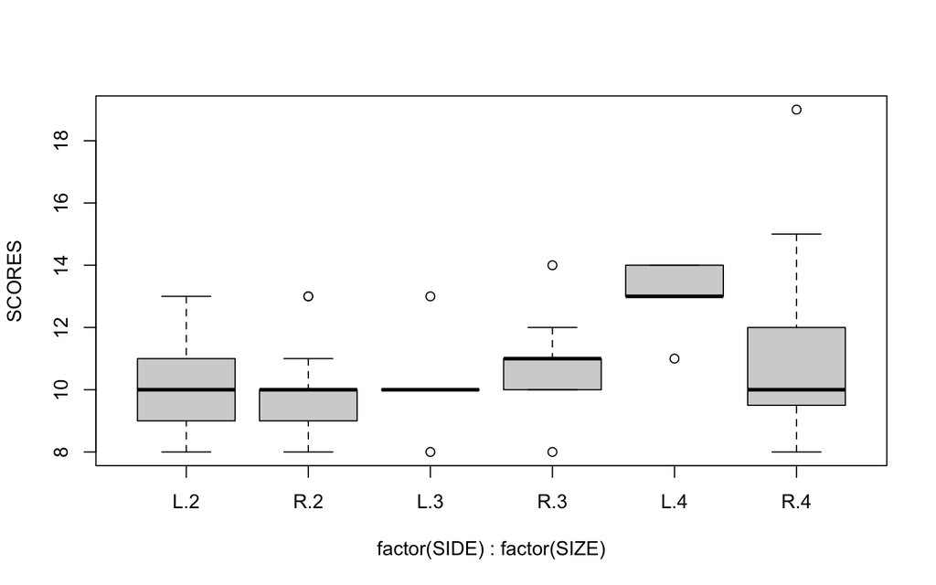

```r
Rev.8.22 <- read_csv("DataSets/ch08_all/REV_C08_22.csv")

boxplot(SCORES ~ factor(SIDE) + factor(SIZE), data = Rev.8.22)
```

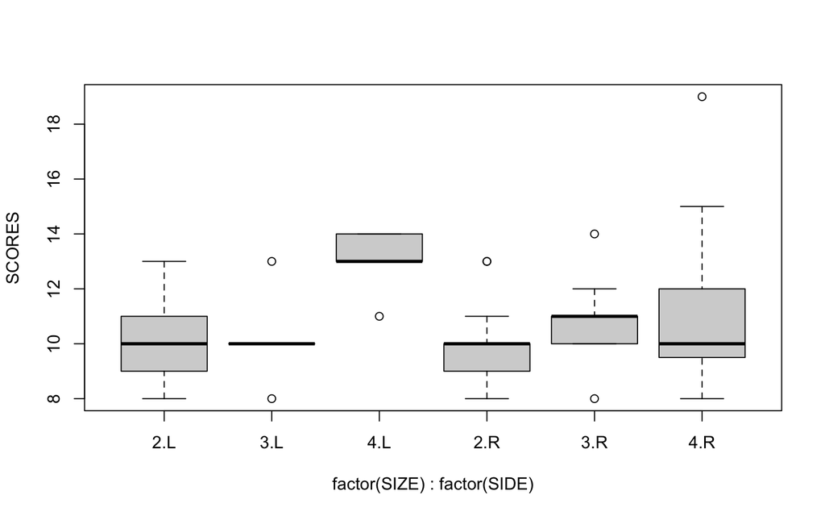

```r
boxplot(SCORES ~ factor(SIZE) + factor(SIDE), data = Rev.8.22)
```

```r
#
Rev.8.22_lm <- lm(SCORES ~ factor(SIZE) + factor(SIDE), data = Rev.8.22)
Anova(Rev.8.22_lm)
```

```
Anova Table (Type II tests)

Response: SCORES
              Sum Sq Df F value  Pr(>F)
factor(SIZE)  29.981  2  3.6673 0.03265 *
factor(SIDE)   2.578  1  0.6307 0.43084
Residuals    204.380 50
---
Signif. codes:  0 '***' 0.001 '**' 0.01 '*' 0.05 '.' 0.1 ' ' 1
```

```r
S(Rev.8.22_lm)
```

```
Call: lm(formula = SCORES ~ factor(SIZE) + factor(SIDE), data = Rev.8.22)

Coefficients:
              Estimate Std. Error t value Pr(>|t|)
(Intercept)    10.2796     0.5492  18.717  < 2e-16 ***
factor(SIZE)3   0.5871     0.6856   0.856  0.39590
factor(SIZE)4   1.7505     0.6491   2.697  0.00951 **
factor(SIDE)R  -0.4593     0.5783  -0.794  0.43084
---
Signif. codes:  0 '***' 0.001 '**' 0.01 '*' 0.05 '.' 0.1 ' ' 1

Residual standard deviation: 2.022 on 50 degrees of freedom
Multiple R-squared: 0.1327
F-statistic:  2.55 on 3 and 50 DF,  p-value: 0.06615
   AIC    BIC
235.12 245.06
```

```r
# contrasts
emmeans(Rev.8.22_lm, pairwise ~ SIDE + SIZE)
```

```
$emmeans
 SIDE SIZE emmean    SE df lower.CL upper.CL
 L       2  10.28 0.549 50     9.18     11.4
 R       2   9.82 0.478 50     8.86     10.8
 L       3  10.87 0.656 50     9.55     12.2
 R       3  10.41 0.578 50     9.25     11.6
 L       4  12.03 0.638 50    10.75     13.3
 R       4  11.57 0.519 50    10.53     12.6

Confidence level used: 0.95

$contrasts
 contrast  estimate    SE df t.ratio p.value
 L 2 - R 2    0.459 0.578 50  0.794  0.9672
 L 2 - L 3   -0.587 0.686 50 -0.856  0.9550
 L 2 - R 3   -0.128 0.884 50 -0.145  1.0000
 L 2 - L 4   -1.751 0.649 50 -2.697  0.0938
 L 2 - R 4   -1.291 0.831 50 -1.554  0.6320
 R 2 - L 3   -1.046 0.910 50 -1.150  0.8576
 R 2 - R 3   -0.587 0.686 50 -0.856  0.9550
 R 2 - L 4   -2.210 0.906 50 -2.439  0.1627
 R 2 - R 4   -1.751 0.649 50 -2.697  0.0938
 L 3 - R 3    0.459 0.578 50  0.794  0.9672
 L 3 - L 4   -1.163 0.731 50 -1.592  0.6072
 L 3 - R 4   -0.704 0.909 50 -0.775  0.9706
 R 3 - L 4   -1.623 0.954 50 -1.701  0.5378
 [ reached getOption("max.print") -- omitted 2 rows ]

P value adjustment: tukey method for comparing a family of 6 estimates
```

```r
Rev.8.22_lm_int <- lm(SCORES ~ factor(SIZE) * factor(SIDE), data = Rev.8.22)
S(Rev.8.22_lm_int)
```

```
Call: lm(formula = SCORES ~ factor(SIZE) * factor(SIDE), data = Rev.8.22)

Coefficients:
                            Estimate Std. Error t value Pr(>|t|)
(Intercept)                 10.11111    0.66985  15.095   <2e-16 ***
factor(SIZE)3                0.08889    1.12088   0.079   0.9371
factor(SIZE)4                2.88889    1.12088   2.577   0.0131 *
factor(SIDE)R               -0.18254    0.85858  -0.213   0.8325
factor(SIZE)3:factor(SIDE)R  0.76032    1.41192   0.538   0.5927
factor(SIZE)4:factor(SIDE)R -1.65079    1.37162  -1.204   0.2347
---
Signif. codes:  0 '***' 0.001 '**' 0.01 '*' 0.05 '.' 0.1 ' ' 1

Residual standard deviation: 2.01 on 48 degrees of freedom
Multiple R-squared: 0.1774
F-statistic: 2.071 on 5 and 48 DF,  p-value: 0.08548
   AIC    BIC
236.26 250.18
```

```r
#
emmeans(Rev.8.22_lm_int, trt.vs.ctrl ~ SIZE + SIDE)
```

```
$emmeans
 SIZE SIDE emmean    SE df lower.CL upper.CL
    2 L     10.11 0.670 48     8.76     11.5
    3 L     10.20 0.899 48     8.39     12.0
    4 L     13.00 0.899 48    11.19     14.8
    2 R      9.93 0.537 48     8.85     11.0
    3 R     10.78 0.670 48     9.43     12.1
    4 R     11.17 0.580 48    10.00     12.3

Confidence level used: 0.95

$contrasts
 contrast  estimate    SE df t.ratio p.value
 3 L - 2 L   0.0889 1.121 48  0.079  0.9996
 4 L - 2 L   2.8889 1.121 48  2.577  0.0548
 2 R - 2 L  -0.1825 0.859 48 -0.213  0.9950
 3 R - 2 L   0.6667 0.947 48  0.704  0.8853
 4 R - 2 L   1.0556 0.886 48  1.191  0.6210

P value adjustment: dunnettx method for 5 tests
```

```r
# With rstatix
Rev.8.22_aov <- anova_test(data = Rev.8.22, SCORES ~ factor(SIZE) + factor(SIDE))
get_anova_table(Rev.8.22_aov)
```

```
ANOVA Table (type II tests)

        Effect DFn DFd     F     p p<.05   ges
1 factor(SIZE)   2  50 3.667 0.033     * 0.128
2 factor(SIDE)   1  50 0.631 0.431       0.012
```

```r
emmeans_test(Rev.8.22, SCORES ~ SIZE, p.adjust.method = "fdr")
```

```
# A tibble: 3 x 9
  term  .y.    group1 group2    df statistic      p  p.adj p.adj.signif
* <chr> <chr>  <chr>  <chr>  <dbl>     <dbl>  <dbl>  <dbl> <chr>
1 SIZE  SCORES 2      3         51    -0.837 0.407  0.407  ns
2 SIZE  SCORES 2      4         51    -2.65  0.0108 0.0323 *
3 SIZE  SCORES 3      4         51    -1.56  0.125  0.187  ns
```

**Ejemplo 18** The effects of thermal pollution on Corbicula fluminea (Asiatic clams) at three different geographical locations were analyzed by John Brooker (REV_C08_18). Sample data on clam shell length, width, and height are displayed in the following table. Determine if there is a significant difference in mean length, height, or width (measured in mm) of the clam shell at the three different locations by performing three analyses. What inferences can be made from your results? What are the assumptions underlying your inferences? What are the target populations?

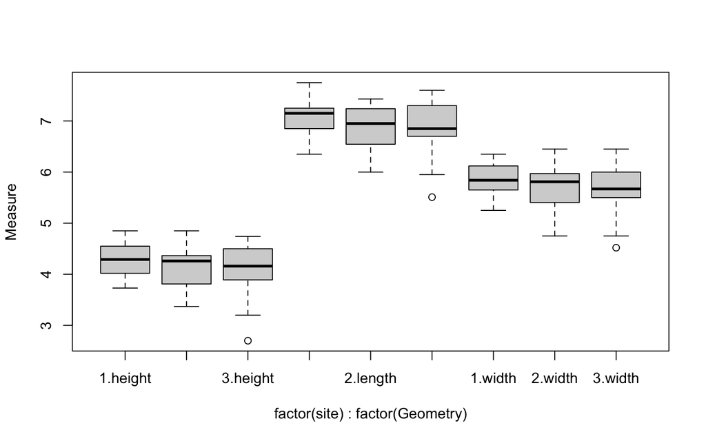

```r
Rev.8.18 <- read.csv("DataSets/ch08_all/REV_C08_18_mod.csv")
boxplot(Measure ~ factor(site) + factor(Geometry), data = Rev.8.18)
```

```r
Rev.8.18_lm <- lm(Measure ~ factor(site) + factor(Geometry), data = Rev.8.18)
S(Rev.8.18_lm)
```

```
Call: lm(formula = Measure ~ factor(site) + factor(Geometry), data = Rev.8.18)

Coefficients:
                       Estimate Std. Error t value Pr(>|t|)
(Intercept)             4.29952    0.06416  67.007  < 2e-16 ***
factor(site)2          -0.17676    0.07161  -2.468  0.01434 *
factor(site)3          -0.20611    0.06942  -2.969  0.00332 **
factor(Geometry)length  2.77419    0.07057  39.310  < 2e-16 ***
factor(Geometry)width   1.55405    0.07057  22.021  < 2e-16 ***
---
Signif. codes:  0 '***' 0.001 '**' 0.01 '*' 0.05 '.' 0.1 ' ' 1

Residual standard deviation: 0.4293 on 217 degrees of freedom
Multiple R-squared: 0.8781
F-statistic: 390.7 on 4 and 217 DF,  p-value: < 2.2e-16
   AIC    BIC
261.48 281.89
```

```r
# Pairwise
emmeans(Rev.8.18_lm, pairwise ~ site + Geometry)
```

```
$emmeans
 site Geometry emmean     SE  df lower.CL upper.CL
    1 height     4.30 0.0642 217     4.17     4.43
    2 height     4.12 0.0658 217     3.99     4.25
    3 height     4.09 0.0634 217     3.97     4.22
    1 length     7.07 0.0642 217     6.95     7.20
    2 length     6.90 0.0658 217     6.77     7.03
    3 length     6.87 0.0634 217     6.74     6.99
    1 width      5.85 0.0642 217     5.73     5.98
    2 width      5.68 0.0658 217     5.55     5.81
    3 width      5.65 0.0634 217     5.52     5.77

Confidence level used: 0.95

$contrasts
 contrast            estimate     SE  df t.ratio p.value
 1 height - 2 height   0.1768 0.0716 217   2.468 0.2534
 1 height - 3 height   0.2061 0.0694 217   2.969 0.0788
 1 height - 1 length  -2.7742 0.0706 217 -39.310 <.0001
 1 height - 2 length  -2.5974 0.1005 217 -25.835 <.0001
 1 height - 3 length  -2.5681 0.0990 217 -25.942 <.0001
 1 height - 1 width   -1.5541 0.0706 217 -22.021 <.0001
 1 height - 2 width   -1.3773 0.1005 217 -13.699 <.0001
 1 height - 3 width   -1.3479 0.0990 217 -13.616 <.0001
 2 height - 3 height   0.0294 0.0709 217   0.414 1.0000
 2 height - 1 length  -2.9509 0.1005 217 -29.351 <.0001
 2 height - 2 length  -2.7742 0.0706 217 -39.310 <.0001
 2 height - 3 length  -2.7448 0.1001 217 -27.430 <.0001
 2 height - 1 width   -1.7308 0.1005 217 -17.215 <.0001
 [ reached getOption("max.print") -- omitted 23 rows ]

P value adjustment: tukey method for comparing a family of 9 estimates
```

**Ejemplo** Licciardone et al. examined subjects with chronic, nonspecific low back pain. In this study, 18 of the subjects completed a survey questionnaire assessing physical functioning at baseline, and after 1, 3, and 6 months. Table (EXA_C08_S04_01) shows the data for these subjects who received a sham treatment that appeared to be genuine osteopathic manipulation. Higher values indicate better physical functioning. The goal of the experiment was to determine if subjects would report improvement over time even though the treatment they received would provide minimal improvement. We wish to know if there is a difference in the mean survey values among the four points in time.

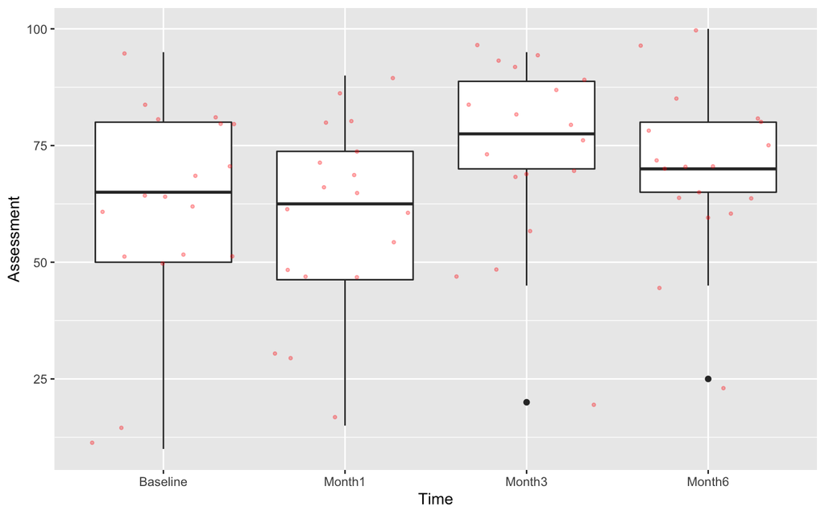

```r
Exa8.4.1 <- read.csv("DataSets/ch08_all/EXA_C08_S04_01mod.csv")

ggplot( data = Exa8.4.1, aes(x = Time, y = Assessment) ) + geom_boxplot() +
     scale_fill_viridis(discrete = TRUE, alpha=0.6) +
     geom_jitter(color="red", size=0.8, alpha=0.3)
```

```r
# Find outliers (extreme if present)
Exa8.4.1 %>%
  group_by(Time) %>%
  identify_outliers(Assessment)
```

```
# A tibble: 2 x 5
  Time   Assessment Subject is.outlier is.extreme
  <chr>       <int>   <int> <lgl>      <lgl>
1 Month3         20      16 TRUE       FALSE
2 Month6         25      16 TRUE       FALSE
```

```r
# Test normal distribution
Exa8.4.1 %>%
  group_by(Time) %>%
  shapiro_test(Assessment)
```

```
# A tibble: 4 x 4
  Time     variable   statistic      p
  <chr>    <chr>          <dbl>  <dbl>
1 Baseline Assessment     0.900 0.0568
2 Month1   Assessment     0.960 0.611
3 Month3   Assessment     0.884 0.0303
4 Month6   Assessment     0.935 0.235
```

```r
# ANOVA test from the rstatix package
Exa8.4.1_aov <- anova_test(data = Exa8.4.1, dv = Assessment, wid = Subject, within = Time)
get_anova_table(Exa8.4.1_aov)
```

```
ANOVA Table (type III tests)

  Effect  DFn   DFd     F     p p<.05  ges
1   Time 2.22 37.68 5.501 0.006     * 0.08
```

```r
# Pairwise comparisons
emmeans_test(Exa8.4.1, Assessment ~ Time, p.adjust.method = "fdr")
```

```
# A tibble: 6 x 9
  term  .y.        group1   group2    df statistic      p p.adj p.adj.signif
* <chr> <chr>      <chr>    <chr>  <dbl>     <dbl>  <dbl> <dbl> <chr>
1 Time  Assessment Baseline Month1    68     0.372 0.711  0.711 ns
2 Time  Assessment Baseline Month3    68    -1.74  0.0871 0.242 ns
3 Time  Assessment Baseline Month6    68    -1.20  0.235  0.352 ns
4 Time  Assessment Month1   Month3    68    -2.11  0.0387 0.232 ns
5 Time  Assessment Month1   Month6    68    -1.57  0.121  0.242 ns
6 Time  Assessment Month3   Month6    68     0.537 0.593  0.711 ns
```

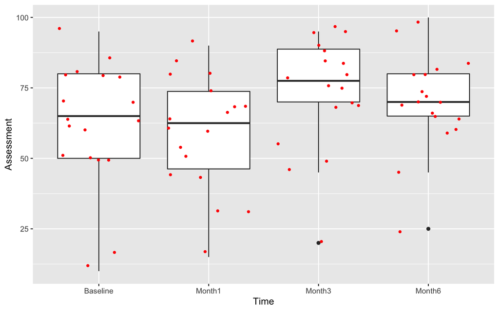

```r
# # # # # # # # # # # # # # # # # # #
# Now with the R basic anova function, how to make a repeated measures
ggplot( data = Exa8.4.1, aes(x = Time, y = Assessment) ) + geom_boxplot() +
  scale_fill_viridis(discrete = TRUE, alpha=0.9) +
  geom_jitter(color="red", size=1., alpha=1.)
```

```r
Exa8.4.1_mod <- aov( Assessment ~ factor(Time) + Error(factor(Subject)), data = Exa8.4.1 )
#
summary(Exa8.4.1_mod)
```

```
Error: factor(Subject)
          Df Sum Sq Mean Sq F value Pr(>F)
Residuals 17  20238    1190

Error: Within
             Df Sum Sq Mean Sq F value  Pr(>F)
factor(Time)  3   2396   798.6   5.501 0.00237 **
Residuals    51   7404   145.2
---
Signif. codes:  0 '***' 0.001 '**' 0.01 '*' 0.05 '.' 0.1 ' ' 1
```

```r
# emmeans(Exa8.4.1_mod, pairwise ~ Time)
# emmeans(Exa8.4.1_mod, trt.vs.crtl ~ Time)
```